# Project: Investigate a Dataset (Replace this with something more specific!)

#### Data Checking

> Using Unique() function to confirm that all data in this dataset make sence.

```python
print("Gender: ", np.sort(df.Gender.unique())) # sorting the unique data of gender to confirm if it's ok or not
```

```
Gender:  ['F' 'M']
```

Gender in this dataset set either Female or Male.

```python
print("Age: ", np.sort(df.Age.unique())) # sorting the unique data of age to confirm if it's ok or not
```

```
Age:  [ -1   0   1   2   3   4   5   6   7   8   9  10  11  12  13  14  15  16
  17  18  19  20  21  22  23  24  25  26  27  28  29  30  31  32  33  34
  35  36  37  38  39  40  41  42  43  44  45  46  47  48  49  50  51  52
  53  54  55  56  57  58  59  60  61  62  63  64  65  66  67  68  69  70
  71  72  73  74  75  76  77  78  79  80  81  82  83  84  85  86  87  88
  89  90  91  92  93  94  95  96  97  98  99 100 102 115]
```

Age column have (-1) which is not a valid value, and to make sure we gonna run the below statment to make sure that it's a human error in data entery level:

```python
df.query('Age == "-1"') # to query rows with age = -1
```

|  | PatinetID | AppointmentID | Gender | ScheduledDay | AppointmentDay | Age | Neighbourhood | Scholarship | Hypertension | Diabetes | Alcoholism | Handicap | SMSReceived | NoShow | ScheduledDayOfWeek | AppointmentDayOfWeek |
| --- | --- | --- | --- | --- | --- | --- | --- | --- | --- | --- | --- | --- | --- | --- | --- | --- |
| 99832 | 465943158731293 | 5775010 | F | 2016-06-06 08:58:13 | 2016-06-06 | -1 | ROMÃO | 0 | 0 | 0 | 0 | 0 | 0 | No | Monday | Monday |

And to fix that isuue we gonna drop the row.

```python
df.drop(index=99832, inplace=True) # drop rows with index = 99842 and age = -1
```

```python
df.query('Age == "-1"') # query again for age = -1
```

|  | PatinetID | AppointmentID | Gender | ScheduledDay | AppointmentDay | Age | Neighbourhood | Scholarship | Hypertension | Diabetes | Alcoholism | Handicap | SMSReceived | NoShow | ScheduledDayOfWeek | AppointmentDayOfWeek |
| --- | --- | --- | --- | --- | --- | --- | --- | --- | --- | --- | --- | --- | --- | --- | --- | --- |

After double checking it's seems that everything OK and we can continue our work.

```python
print("Neighbourhood : ", np.sort(df.Neighbourhood.unique())) # sorting the unique data of neighbourhood to confirm if it's ok or not
```

```
Neighbourhood :  ['AEROPORTO' 'ANDORINHAS' 'ANTÔNIO HONÓRIO' 'ARIOVALDO FAVALESSA'
 'BARRO VERMELHO' 'BELA VISTA' 'BENTO FERREIRA' 'BOA VISTA' 'BONFIM'
 'CARATOÍRA' 'CENTRO' 'COMDUSA' 'CONQUISTA' 'CONSOLAÇÃO' 'CRUZAMENTO'
 'DA PENHA' 'DE LOURDES' 'DO CABRAL' 'DO MOSCOSO' 'DO QUADRO'
 'ENSEADA DO SUÁ' 'ESTRELINHA' 'FONTE GRANDE' 'FORTE SÃO JOÃO' 'FRADINHOS'
 'GOIABEIRAS' 'GRANDE VITÓRIA' 'GURIGICA' 'HORTO' 'ILHA DAS CAIEIRAS'
 'ILHA DE SANTA MARIA' 'ILHA DO BOI' 'ILHA DO FRADE' 'ILHA DO PRÍNCIPE'
 'ILHAS OCEÂNICAS DE TRINDADE' 'INHANGUETÁ' 'ITARARÉ' 'JABOUR'
 'JARDIM CAMBURI' 'JARDIM DA PENHA' 'JESUS DE NAZARETH' 'JOANA D´ARC'
 'JUCUTUQUARA' 'MARIA ORTIZ' 'MARUÍPE' 'MATA DA PRAIA' 'MONTE BELO'
 'MORADA DE CAMBURI' 'MÁRIO CYPRESTE' 'NAZARETH' 'NOVA PALESTINA'
 'PARQUE INDUSTRIAL' 'PARQUE MOSCOSO' 'PIEDADE' 'PONTAL DE CAMBURI'
 'PRAIA DO CANTO' 'PRAIA DO SUÁ' 'REDENÇÃO' 'REPÚBLICA' 'RESISTÊNCIA'
 'ROMÃO' 'SANTA CECÍLIA' 'SANTA CLARA' 'SANTA HELENA' 'SANTA LUÍZA'
 'SANTA LÚCIA' 'SANTA MARTHA' 'SANTA TEREZA' 'SANTO ANDRÉ' 'SANTO ANTÔNIO'
 'SANTOS DUMONT' 'SANTOS REIS' 'SEGURANÇA DO LAR' 'SOLON BORGES'
 'SÃO BENEDITO' 'SÃO CRISTÓVÃO' 'SÃO JOSÉ' 'SÃO PEDRO' 'TABUAZEIRO'
 'UNIVERSITÁRIO' 'VILA RUBIM']
```

```python
print("Neighbourhood Count: ", np.count_nonzero(df.Neighbourhood.unique())) # count of neighbourhood
```

```
Neighbourhood Count:  81
```

```python
print("Scholarship : ", np.sort(df.Scholarship.unique())) # sorting the unique data of scholarship to confirm if it's ok or not
```

```
Scholarship :  [0 1]
```

```python
# sorting the unique data of conditions to confirm if it's ok or not
print("Hypertension : ", np.sort(df.Hypertension.unique()))
print("\nDiabetes : ", np.sort(df.Diabetes.unique()))
print("\nAlcoholism : ", np.sort(df.Alcoholism.unique()))
print("\nHandicap : ", np.sort(df.Handicap.unique()))
```

```
Hypertension :  [0 1]

Diabetes :  [0 1]

Alcoholism :  [0 1]

Handicap :  [0 1 2 3 4]
```

```python
print("SMSReceived : ", np.sort(df.SMSReceived.unique())) # sorting the unique data of sms received to confirm if it's ok or not
```

```
SMSReceived :  [0 1]
```

```python
print("NoShow : ", np.sort(df.NoShow.unique())) # sorting the unique data of no show to confirm if it's ok or not
```

```
NoShow :  ['No' 'Yes']
```

So far so good, every columns seems to have the right entries.

```python
# sorting the unique data of day of week to confirm if it's ok or not
print("ScheduledDayOfWeek : ", np.sort(df.ScheduledDayOfWeek.unique()))
print("\nAppointmentDayOfWeek : ", np.sort(df.AppointmentDayOfWeek.unique()))
```

```
ScheduledDayOfWeek :  ['Friday' 'Monday' 'Saturday' 'Thursday' 'Tuesday' 'Wednesday']

AppointmentDayOfWeek :  ['Friday' 'Monday' 'Saturday' 'Thursday' 'Tuesday' 'Wednesday']
```

These two columns are the last two in this dataset and they give the right entries.

## Exploratory Data Analysis

#### Which gender is more likely to miss the appointment?

To answer this question, we need to split the dataset into two seperate parts and count for each gender.

```python
# create dataframe with gender = female and no show = missing
df_Female = df.query('Gender == "F" and NoShow == "Yes"')
Gender_F = df_Female['Gender'].value_counts() # count the values of gender
Gender_F
```

```
F    14594
Name: Gender, dtype: int64
```

```python
# create dataframe with gender = male and no show = missing
df_Male = df.query('Gender == "M" and NoShow == "Yes"')
Gender_M = df_Male['Gender'].value_counts()
Gender_M
```

```
M    7725
Name: Gender, dtype: int64
```

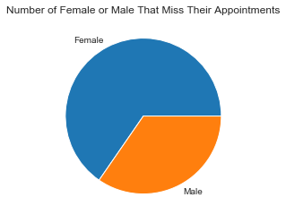

```python
plt.pie([Gender_F, Gender_M], labels=["Female", "Male"]);
plt.title("Number of Female or Male That Miss Their Appointments");
```

#### Are patinets with Hypertension, Diabetes, Alcoholism, or Handicap likely to come?

```python
# create dataframe with conditions = 1 and they miss the appointmnet
ConditionYES = df.query('(Hypertension == 1 or Diabetes == 1 or Alcoholism == 1 or Handicap == 1) and NoShow == "Yes"')
ConditionYESCount = ConditionYES.groupby('Gender').count()['Age'] # group by gender
ConditionYESCount
```

```
Gender
F    3168
M    1532
Name: Age, dtype: int64
```

```python
# create dataframe with conditions = 1 and they attend the appointmnet
ConditionNO = df.query('(Hypertension == 1 or Diabetes == 1 or Alcoholism == 1 or Handicap == 1) and NoShow == "No"')
ConditionNOCount = ConditionNO.groupby('Gender').count()['Age']
ConditionNOCount
```

```
Gender
F    14425
M     7178
Name: Age, dtype: int64
```

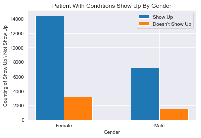

```python
index = np.array([1,2])
width = 0.3
place = ['Female', 'Male']
plt.bar(index, ConditionNOCount, width=width, label='Show Up')
plt.bar(index + width, ConditionYESCount, width=width, label="Doesn't Show Up")

place = index + (width / 2)
plt.xticks(place, ['Female', 'Male'])
plt.title("Patient With Conditions Show Up By Gender")
plt.xlabel("Gender")
plt.ylabel("Counting of Show Up \ Not Show Up")

plt.legend(bbox_to_anchor=(1,1));
```

#### Which day of the week patients more likely to not show up for their appointments?

```python
# create dataframe with day of the week and count of the patinet miss\attend the appointmnet
dow = df.groupby(['AppointmentDayOfWeek', 'NoShow']).count()['Age']
dowMondayNO = dow['Monday', 'No']
dowMondayYES = dow['Monday', 'Yes']
dowTuesdayNO = dow['Tuesday', 'No']
dowTuesdayYES = dow['Tuesday', 'Yes']
dowWednesdayNO = dow['Wednesday', 'No']
dowWednesdayYES = dow['Wednesday', 'Yes']
dowThursdayNO = dow['Thursday', 'No']
dowThursdayYES = dow['Thursday', 'Yes']
dowFridayNO = dow['Friday', 'No']
dowFridayYES = dow['Friday', 'Yes']
dowSaturdayNO = dow['Saturday', 'No']
dowSaturdayYES = dow['Saturday', 'Yes']
```

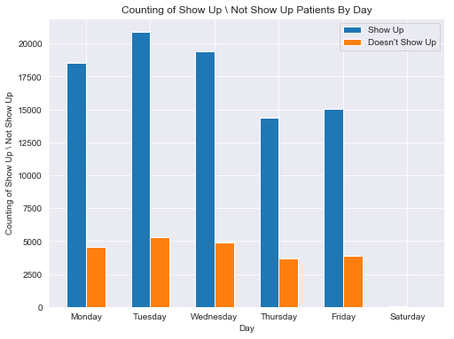

```python
index = np.array([1,2,3,4,5,6])
width = 0.3
plt.subplots(figsize=(8,6))
place = ['Monday', 'Tuesday', 'Wednesday', 'Thursday', 'Friday', 'Saturday']
plt.bar(index, [dowMondayNO, dowTuesdayNO, dowWednesdayNO, dowThursdayNO, dowFridayNO, dowSaturdayNO], width=width, label='Show Up')
plt.bar(index + width, [dowMondayYES, dowTuesdayYES, dowWednesdayYES, dowThursdayYES, dowFridayYES, dowSaturdayYES], width=width, label="Doesn't Show Up")

place = index + (width / 2)
plt.xticks(place, ['Monday', 'Tuesday', 'Wednesday', 'Thursday', 'Friday', 'Saturday'])
plt.title("Counting of Show Up \ Not Show Up Patients By Day")
plt.xlabel("Day")
plt.ylabel("Counting of Show Up \ Not Show Up")
plt.legend(bbox_to_anchor=(1,1));
```

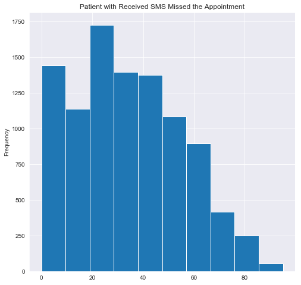

```python
# creat dataframe with sms received but they miss the appointment
receivedSMS = df.query('SMSReceived == 1 and NoShow == "Yes"')
receivedSMS.Age.plot(kind='hist', x='Age', y='Count How Many Patient Miss The Apointments', title="Patient with Received SMS Missed the Appointment", figsize=(8,8));
```